# Econometrics HW #1 Solutions

### d. How many different classes are in the data, and how many cars from each class?

```r
# create a frequency table of 'class' categorical variable in mpg dataset
table(mpg$class)
```

```
##
##    2seater    compact    midsize    minivan     pickup subcompact
##          5         47         41         11         33         35
##        suv
##         62
```

### e. Plot two histograms, one of `hwy` and one of `cty`

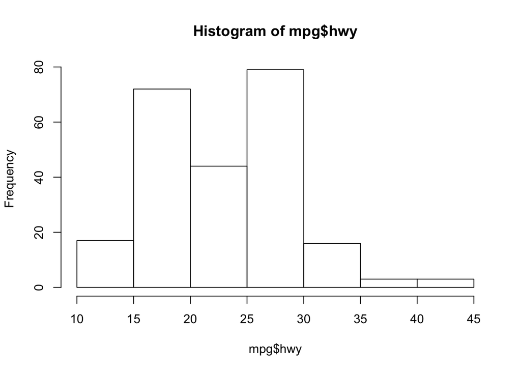

```r
hist(mpg$hwy) # create histogram of 'hwy' variable from mpg dataset
```

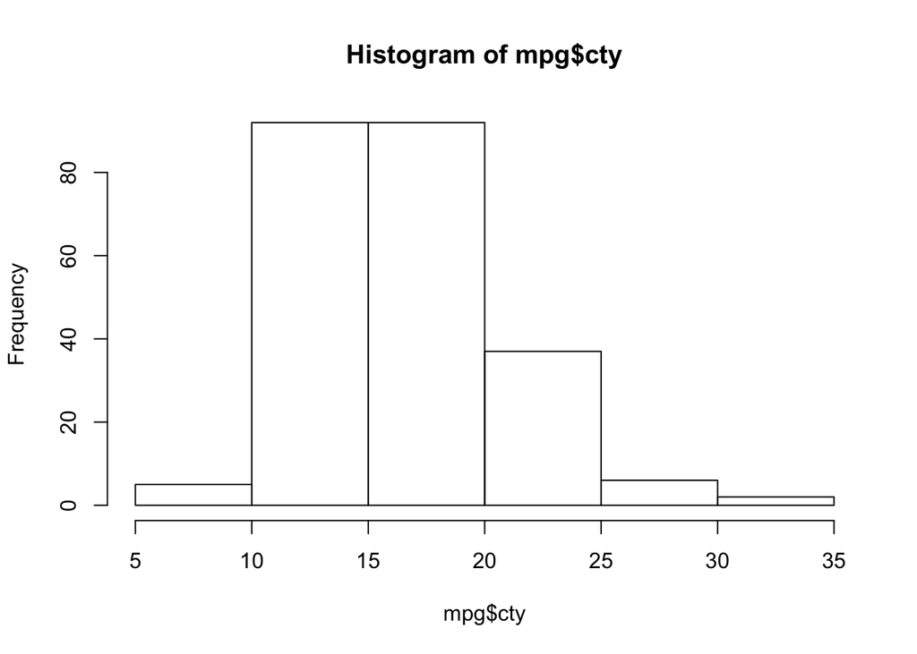

```r
hist(mpg$cty) # create histogram of 'cty' variable from mpg dataset
```

### f. Plot a boxplot of `hwy` mpg by `manufacturer`. Which manufacturer appears to have the highest average highway mpg? Which appears to have the largest variance? Which appears to have outliers? (There are too many manufacturers for `R` to print them on the axis by default, but they are listed in alphabetical order, check using your answers to part c.)

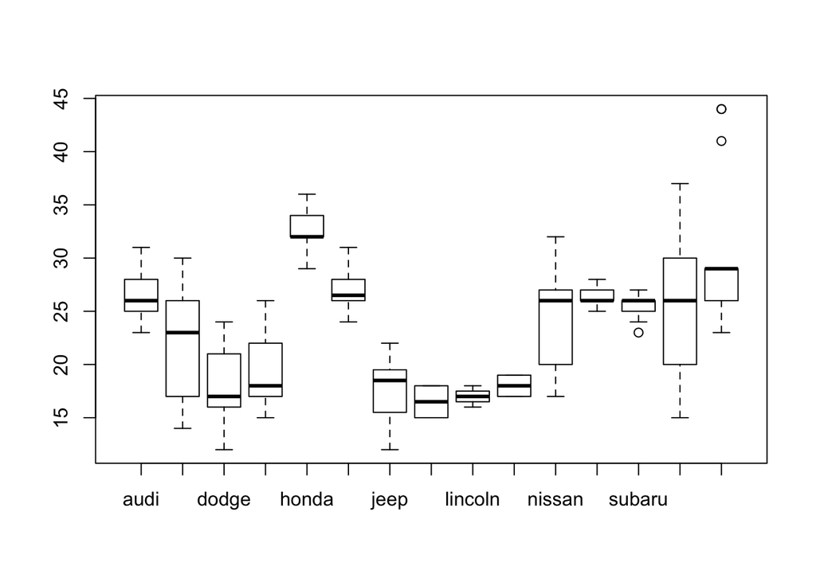

```r
# create a separate boxplot of 'hwy' over every category of 'manufacturer' variable, both from mpg dataset
boxplot(hwy~manufacturer,data=mpg)
```

### g. Plot a boxplot of `hwy` by `class`. Which car classes appear to have the highest average highway mpg? Highest variance?

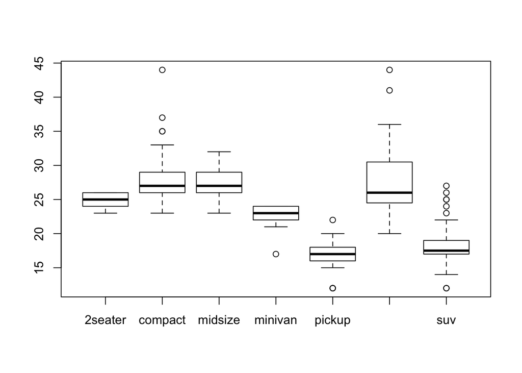

```r
# create a separate boxplot of 'hwy' over every category of 'class' variable, both from mpg dataset
boxplot(hwy~class,data=mpg)
```

***